# Efecto Airbnb en Euskadi: hosts

Este informe se ha generado automáticamente con R a partir del [script de Rmarkdown](https://github.com/montera34/airbneuskadi/tree/master/analisis/hosts-analysis.Rmd) disponible en el [repositorio airbnbeuskadi](https://github.com/montera34/airbneuskadi).

## Datos

- Datahippo.com Euskadi
- Fecha scraping: 2018-09-26

## Resumen

En **Euskadi** se han publicado 6.536 anuncios de Airbnb desde que Datahippo guarda registro, que han tenido capacidad para 26.610 plazas (accommodates).

De esos anuncios 0 tienen rellena la parte de la licencia (lo que supone un 0,0% del municipio), lo que no quiere decir que todas esas licencias indicadas sean válidas.

Estos anuncios (listings, en la terminología de Airbnb) han sido publicados por 3.832 anfitriones.

PERO

De esos 6.536 anuncios han sido “encontrados” como disponibles por el scraping de Datahippo con fecha posterior (ver siguiente tabla):

| fecha | nº anuncios encontrados | % respecto total |
| --- | --- | --- |
| 2017-09-01 | 6.536 | 100 |
| 2017-10-01 | 5.007 | 76,6 |
| 2017-11-01 | 5.004 | 76,6 |
| 2017-12-01 | 5.004 | 76,6 |
| 2018-01-01 | 5.004 | 76,6 |
| 2018-02-01 | 5.004 |  |
| 2018-03-01 | 5.004 |  |
| 2018-04-01 | 5.004 |  |
| 2018-05-01 | 4.853 | 74,3 |
| 2018-06-01 | 4.208 | 64,4 |
| 2018-07-01 | 3.383 | 51,8 |
| 2018-08-01 | 3.383 |  |
| 2018-09-01 | 3.383 |  |
| 2018-09-15 | 3.383 | 51,8 |
| 2018-09-20 | 1.620 | 24,8 |

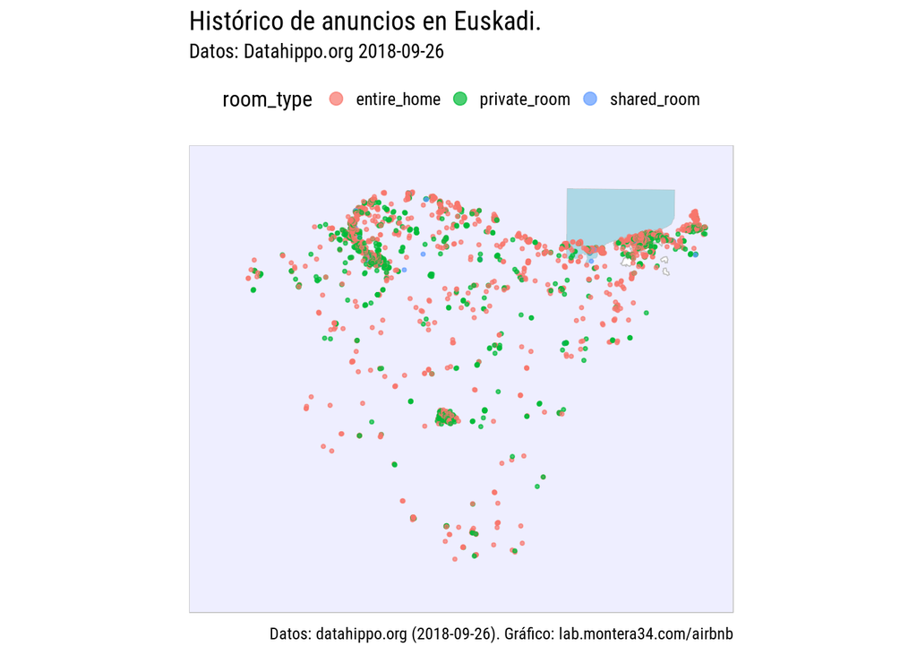

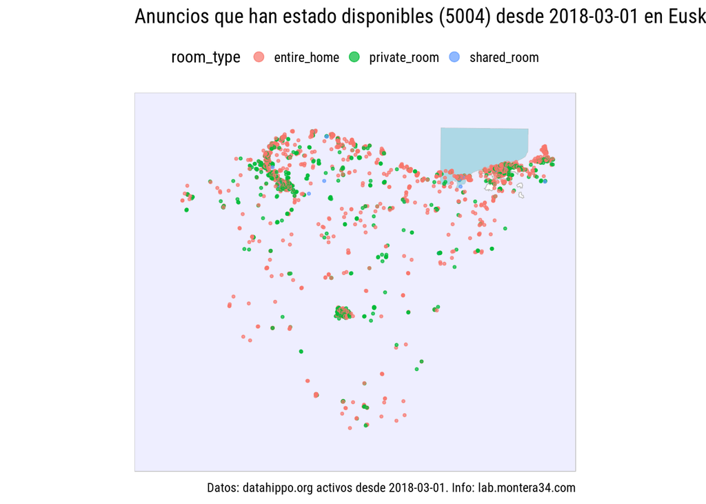

### Los anfitriones con más alojamientos

Calculado por anuncios activos desde 2018-03-01.

Los 25 anfitriones con más alojamientos

| host.id | alojamientos | plazas |
| --- | --- | --- |
| airbnb124008929 | 150 | 764 |
| airbnb15707672 | 76 | 353 |
| airbnb102583389 | 59 | 321 |
| airbnb6598471 | 45 | 264 |
| airbnb13367653 | 30 | 149 |
| airbnb40549256 | 29 | 176 |
| airbnb5254782 | 29 | 110 |
| airbnb98189424 | 28 | 163 |
| airbnb25039584 | 26 | 146 |
| airbnb80463557 | 25 | 122 |
| airbnb790667 | 24 | 59 |
| airbnb105663223 | 23 | 146 |
| airbnb37985139 | 22 | 116 |
| airbnb3952766 | 21 | 73 |
| airbnb4614604 | 21 | 122 |
| airbnb85246818 | 20 | 90 |
| airbnb12954077 | 18 | 118 |
| airbnb3746437 | 17 | 81 |
| airbnb2035832 | 16 | 77 |
| airbnb121027476 | 15 | 70 |
| airbnb62205707 | 15 | 25 |
| airbnb18192487 | 14 | 55 |
| airbnb2470030 | 14 | 89 |
| airbnb117422992 | 13 | 64 |
| airbnb102947901 | 11 | 52 |

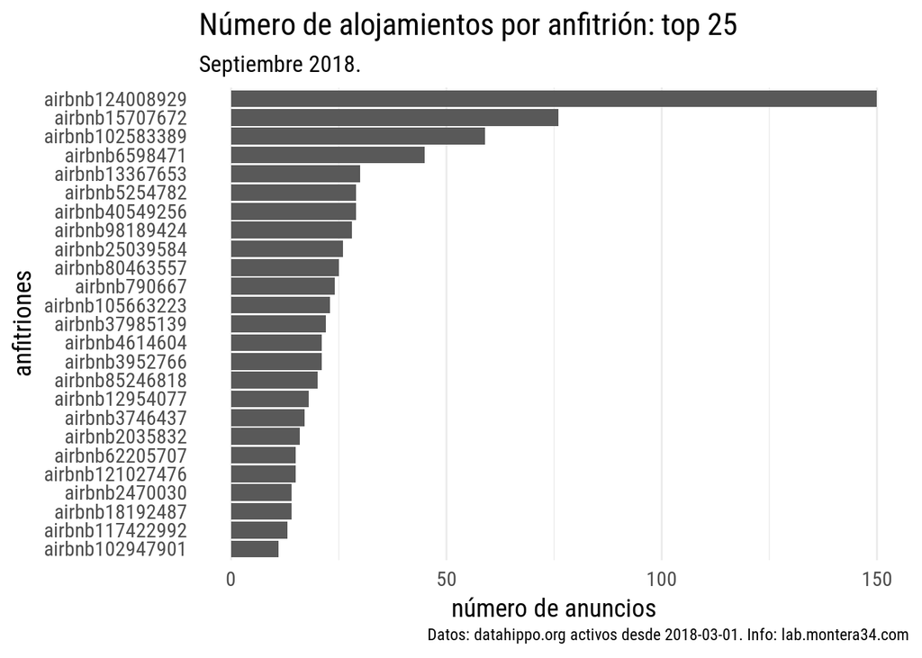

#### En el mapa

##### Top 5

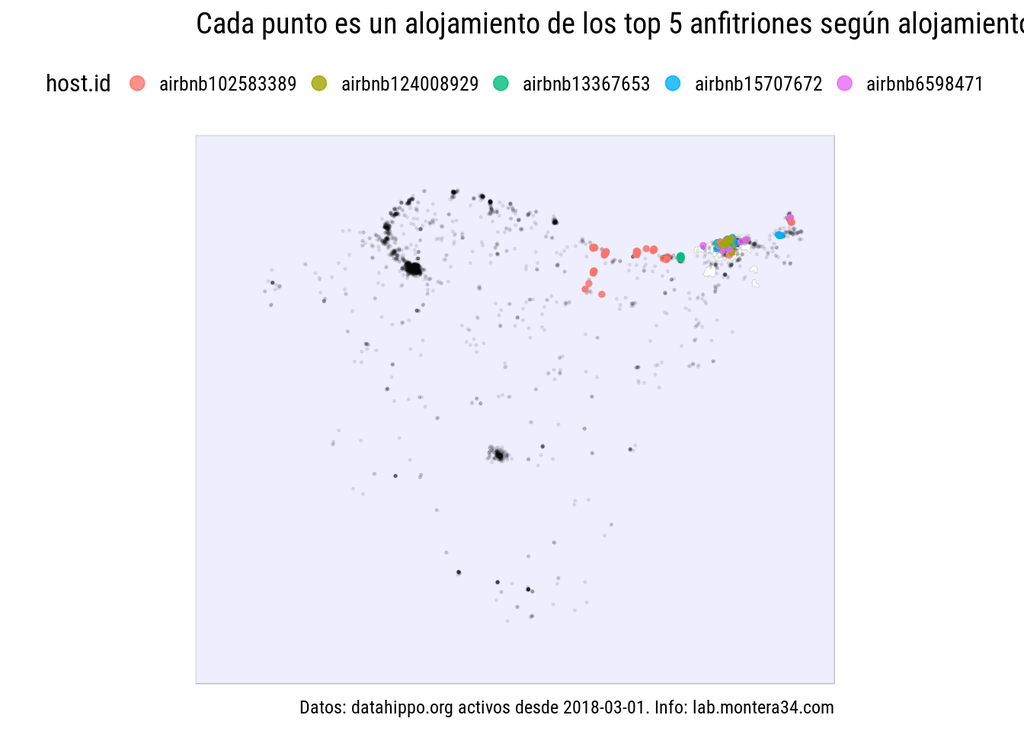

[figure not shown]

[figure not shown]

[figure not shown]

[figure not shown]

[figure not shown]